# TP Projet AC04

Marius Soltane

Mars 2024

# Préalable

## Objectif et déroulé du projet

L’objectif de ce projet est de vous présenter, dans sa version la plus simple, le modèle stochastique appelé **régression linéaire** qui est une des modélisations les plus répandues ; ce modèle permet d’analyser la relation, que l’on suppose **linéaire**, d’une variable par rapport à une autre.

La première section du sujet présente le modèle de régression linéaire simple sans qu’aucune question ne soit posée. La seconde et troisième parties visent à vous faire manipuler les résultats théoriques du modèle de régression linéaire sur des données simulées. La dernière partie consiste à traiter un jeu de données réelles et à discuter de la pertinence du choix de ce modèle de regression linéaire pour la modélisation de la relation entre les deux variables considérées.

## Instructions à suivre

1. **Constitution des groupes.** Vous devez constituer des groupes de 3-4  
   étudiants avec les contraintes suivantes :
   - les groupes sont à former au sein d’un même TP (6 groupes pour T1 et 6 groupes pour T2)
   - pour le groupe T1 : 5 groupes de 4 et 1 groupe de 3 avec au moins 1 IM par groupe
   - pour le groupe T2 : 3 groupes de 4 et 3 groupes de 3 avec au plus 1 IM par groupe

   Si la composition des groupes n’est pas conforme aux consignes formulées ci-dessus, le responsable d’UV se chargera de modifier la composition des groupes.
2. **Déclaration d’un groupe** Un membre de chaque groupe devra envoyer un mail au responsable d’UV pour déclarer l’ensemble des membres de son groupe. Il veillera à mette en copie du mail l’ensemble des membres de son groupe. La date limite pour déclarer un groupe est fixée au **vendredi 29 mars 2024.**
3. **Format du rapport.** Le rapport sera rédigé sous la forme d’un fichier [*RMarkdown*](https://rmarkdown.rstudio.com/articles_intro.html) ou [*quarto*](https://quarto.org/) (l’extension de votre fichier doit être `.rmd` ou `.qmd` selon le type de fichier); un fichier `.rmd` ou `.qmd` est créé à partir du logiciel RStudio. Ce type de fichier permet d’inclure à la fois des lignes de code R et du texte. Vous pourrez vous aider du fichier source disponible sur la page du cours (`Projet_TP_Regression_lin_Etu.rmd` pour la version RMarkdown ou `Projet_TP_Regression_lin_Etu.qmd` pour la verison quarto).
4. **Rédaction du rapport.** Vous devez rédiger votre rapport en conservant la numérotation de ce document; par exemple les réponses aux questions (Q1a), (Q1b),… devront être rédigées dans la section II. de votre rendu de rapport. Par ailleurs, il vous est demandé de faire apparaître dans le fichier compilé `.html` les résultats numériques attendus et les figures tracées.
5. **Rendu du rapport et nom du rapport.** Vous déposerez sur moodle votre rapport sous les formats `.rmd` ou `.qmd` et `.html`. Votre nommerez votre rapport `Rapport_P24_AC04_NOM_ETUDIANT_premier_dans_la_liste_alphabétique_du_groupe`
6. **Date limite.** Vous devrez impérativement déposer votre rapport sur le moodle pour le **vendredi 6 juin 2024 à 23h (heure de Paris)** au plus tard (au delà de cette date et heure, le moodle n’acceptera pas votre rapport) ; le non-envoi du rapport implique un zéro à la note d’évaluation de TP pour l’ensemble des étudiants du groupe en question.
7. **Notation du rapport** Dans la note attribuée à chaque projet rendu, seront pris en compte entre autres, la faisabilité de la compilation du ficher `.rmd`/`.qmd` et le respect des consignes (rédaction, format, utilisation d’une fonction particulière sous R,…). Le travail fourni dans le cadre de se projet doit être un travail original. Tout plagiat ou utilisation des modèles d’IA générative (Large Language Models comme ChatGPT) est donc, par conséquence, strictement interdit. Tout manquement sera apprécié au titre de la fraude et fera l’objet de poursuites conformément au règlement des études.
8. **Evaluation du TP** Les soutenances orales se dérouleront le sur la semaine avant les finaux. Les créneaux dédiés aux soutenances ainsi que les modalités seront communiqués ultérieurement

L’évaluation du projet de TP tiendra compte du rapport et de la prestation orale.

- (Q0) Indiquer les noms de membres du groupe ainsi que les pourcentages de la contribution de chacun dans le rendu final de ce projet.
  - Alexandre BIDAUX (GI), contribution : 25 %
  - Julie CHARTIER (GI), contribution : 25 %
  - Chloé LEZAIRE (IM), contribution : 25 %
  - Valentin TESSIER-NAJBOR (IM), contribution : 25 %

# Modèle de régression linéaire simple Gaussien et estimation des paramètres

## Modèle (cf Section 7.2, poly CM)

Supposons que l’on dispose de $n$ couples $(x_1,Y_1),\ldots, (x_n,Y_n)$, avec $x_i\in \mathbb{R}$ et $Y_i$ une v.a. réelle de réalisation $y_i.$ Nous commençons d’abord par une étape de pré-modélisation : la représentation graphique des données qui est un préalable indispensable à la mise en oeuvre de n’importe quelle méthode statistique pour le traitement des données. Si, à partir de la représentation graphique des $(x_i,y_i)_i$, il semble que les $(x_i)_i$ expliquent la majeure partie de la *variabilité* des $(Y_i)_i$ et que le lien entre les $Y_i$ et les $x_i$ est une relation linéaire, cela pourrait revenir à supposer que $\mathbb{E}(Y_i)= a +bx_i$ pour tout $i=1,\ldots,n$. Supposer que $\mathbb{E}(Y_i)= a +bx_i$ pour tout $i=1,\ldots,n$ revient alors à considérer le plus simple des **modèles de régression** à savoir, le modèle de régression linéaire,

$$\begin{align}
Y_i = a + b x_i + \epsilon_i, \; \text{avec} \;
\mathbb{E}(\epsilon_i)=0, \; \forall i=1,\ldots,n, \quad (1)
\end{align}$$
où les $(\epsilon_i)_i$ sont appelés les “erreurs” ou “bruits” du modèle.

Sur le modèle (1), nous formulons les hypothèses suivantes $(\mathcal{ H})$ :

1. Indépendance des erreurs $\epsilon_1,\ldots,\epsilon_n$
2. Normalité des erreurs $\epsilon_1,\ldots,\epsilon_n$
3. Homoscédasticité, c-à-d, les erreurs ont toutes la même variance, soit $\text{Var}(\epsilon_1)=\text{Var}(\epsilon_2)=\ldots=\text{Var}(\epsilon_n)$ et on note $\sigma^2$ leur variance commune.

On considère ainsi le modèle suivant :
$$\begin{align}
Y_i = a + b x_i + \epsilon_i, \ \text{pour tout} \ i =1,\ldots,n, \
\text{avec} \quad &
\epsilon_1,\ldots,\epsilon_n \stackrel{iid}{\sim} \epsilon \ \text{ où
} \; \epsilon \sim \mathcal{ N}(0,\sigma^2). \quad \quad \quad (2)
\end{align}$$
Ce modèle peut se réecrire de façon plus ergonomique via la forme suivante : pour tout $i=1,\ldots,n, \quad Y_i \sim \mathcal{ N}(a + b x_i,\sigma^2)$

Notons que :

- la droite $y=a+bx\stackrel{Déf.}{:}$ droite de régression de $Y$ en $x$ avec $a$ l’intercept (la valeur de la droite à l’origine) et $b$ la pente
- **les paramètres du modèle sont**: $a,\;b$ réels et $\sigma^2>0$

Une fois que le modèle posé, il s’agit d’estimer les paramètres du modèles, puis de valider le modèle retenu et enfin de faire de la prédiction de la valeur de $Y$ sur une valeur de $x$ non encore observée.

## Estimation (cf Section 7.3, poly CM)

1. Méthode du maximum de vraisemblance
- Sous $(\mathcal{H})$, la log-vraisemblance du modèle est :

$$\ell
(a,b,\sigma^2;y_1,\ldots,y_n)=-\frac{n}{2} \log (2\pi \sigma^2) -
\frac{1}{2 \sigma^2}\displaystyle{\sum_{i=1}^n}
(y_i-a-bx_i)^2$$

- Les EMV ${\hat a}, \hat{b}, {\hat\sigma_{MV}^2}$ sont solutions du système d’équations de vraisemblance
  $$\!\!\!\!\!\left\{\begin{array}{l}
  \frac{\partial}{\partial a} \ell(a,b,\sigma^2;y_1,\ldots,y_n) =0 \\
  \frac{\partial}{\partial b} \ell (a,b,\sigma^2;y_1,\ldots,y_n) =0 \\
  \frac{\partial}{\partial \sigma^2} \ell (a,b,\sigma^2;y_1,\ldots,y_n)=0
  \end{array} \right. \!\!\! \Leftrightarrow \!\! \left\{\begin{array}{l}
  {\hat a} = {\bar Y} - \displaystyle{\frac{S_{xY}}{s_x^2}{\bar x}}= {\bar
  Y}- {\hat b} {\bar x}\\
  {\hat b} = \displaystyle{\frac{S_{xY}}{s_x^2}} \\
  {\hat\sigma_{MV}^2} =\displaystyle{ \frac{1}{n}\sum_{i=1}^n (Y_i -
  {\hat a} - {\hat b}x_i)^2} \end{array}\right.,$$
  avec
  $$\!\!\!\!\!\left\{ \begin{array}{ll}
  {\bar Y}=\displaystyle{\frac{1}{n}\sum_{i=1}^n Y_i},& S_{xY}=
  \displaystyle{\frac{1}{n}\sum_{i=1}^n (Y_i -{\bar Y})(x_i -{\bar x})=
  (\frac{1}{n}\sum_{i=1}^n x_iY_i) - {\bar x}{\bar Y}} \\
  {\bar y}=\displaystyle{\frac{1}{n}\sum_{i=1}^n y_i},& s_{xy}=
  \displaystyle{\frac{1}{n}\sum_{i=1}^n (y_i -{\bar y})(x_i -{\bar x})=
  (\frac{1}{n}\sum_{i=1}^n x_iy_i) - {\bar x}{\bar y}} \\
  {\bar x}=\displaystyle{\frac{1}{n}\sum_{i=1}^n x_i}, &
  s_x^2 =\displaystyle{\frac{1}{n}\sum_{i=1}^n (x_i-{\bar
  x})^2}=\displaystyle{(\frac{1}{n}\sum_{i=1}^n x_i^2) - {\bar x}^2}
  \end{array}\right.$$
- $y={\hat a} + {\hat b} x \stackrel{Déf.}{:}$ droite des moindres carrés de $Y$ en $x$
- ${\hat a}$ et ${\hat b} \stackrel{Déf.}{:}$ estimateurs des moindres carrés
- Notations. Pour tout $i =1,\dots,n$, ${\hat Y}_i = {\hat a} + {\hat b} x_i$ et ${\hat \epsilon}_i=Y_i -{\hat Y}_i$
- $\hookrightarrow \; ({\hat \epsilon}_i)_{1 \leq i\leq n}\stackrel{Déf.}{:}$ résidus
- $\hookrightarrow \; {\hat Y_i}$ est un estimateur de $\mathbb{E}(Y_i)$
- **Propriété des résidus**

  $${\bar y}={\hat a} + {\hat b} {\bar x}\;
  \;\Rightarrow \; \;\displaystyle{\sum_{i=1}^n {\hat y}_i = \sum_{i=1}^n
  y_i} \; \;\; \; \Rightarrow\; \;\; \; \displaystyle{\sum_{i=1}^n {\hat
  \epsilon}_i= \sum_{i=1}^n (y_i -{\hat y}_i)=0}$$

## Propriétés des estimateurs et I.C. (cf Section 7.4 et 7.5, poly CM)

- ${\hat a}$ et ${\hat b}$ sont des **estimateurs sans biais** de $a$ et $b$ ;
- ${\hat \sigma}^2$ estimateur sans biais de $\sigma^2$ :

$${\hat
\sigma}^2=\displaystyle{\frac{n}{n-2}}\; {\hat\sigma_{MV}^2}= \;
\displaystyle{ \frac{1}{n-2}\sum_{i=1}^n (Y_i - {\hat a} - {\hat
b}x_i)^2};$$

- **Loi exacte de** ${\hat a}$, ${\hat b}$, ${\hat \sigma}^2$ :
  $${\hat a}\sim {\cal N}(a,\frac{\sigma^2}{n}
  (1+\frac{{\bar x}^2}{s_x^2})), \quad {\hat b} \sim {\cal
  N}(b,\frac{\sigma^2}{ns_x^2}), \quad (n-2)\frac{{\hat
  \sigma}^2}{\sigma^2} \sim \chi^2_{n-2};$$
- ${\rm Cov}({\hat a}, {\hat b})=-\displaystyle{\frac{{\bar x}\sigma^2}{ns_x^2}}$ ;
- $\; ({\hat a}, {\hat b})$ est un vecteur aléatoire Gaussien ;
- ${\hat \sigma}^2$ est indépendant de ${\hat a}$, ${\hat b}$ et ${\bar Y}$ ;
- ${\hat a}$, ${\hat b}$ et ${\hat \sigma}^2$ sont des **estimateurs convergents** de $a$, $b$ et $\sigma^2$ ;
- Fonctions pivotales (exactes) :

$$\displaystyle{\frac{{\hat a} -
a}{\displaystyle{\sqrt{\frac{{\hat \sigma}^2}{n}
(1+\displaystyle{\frac{{\bar x}^2}{s_x^2}})}}}}\sim {\cal T}(n-2), \quad
\quad
\displaystyle{\frac{{\hat b} - b}{\sqrt{\displaystyle{\frac{{\hat
\sigma}^2}{ns_x^2}}}}}
\sim {\cal T}(n-2), \quad \quad
(n-2)\displaystyle{\frac{{\hat \sigma}^2}{\sigma^2}} \sim
\chi^2_{n-2};$$

- $IC^b_{1-\alpha}\stackrel{Déf.}{:}$ IC bilatéral au niveau $1-\alpha$

$$\begin{align*}
IC^b_{1-\alpha}(a) & = {\hat a} \pm t_{n-2,1-\alpha/2}
\sqrt{\frac{{\hat \sigma}^2}{n} (1+\displaystyle{\frac{{\bar
x}^2}{s_x^2})}} \\
IC^b_{1-\alpha}(b) & = {\hat b} \pm t_{n-2,1-\alpha/2}
\sqrt{\frac{{\hat \sigma}^2}{ns_x^2}} \\
IC^b_{1-\alpha}(\sigma^2) &= [\displaystyle{\frac{(n-2){\hat
\sigma}^2}{F^{-1}_{\chi^2_{n-2}}(1-\alpha/2)}},
\displaystyle{\frac{(n-2){\hat
\sigma}^2}{F^{-1}_{\chi^2_{n-2}}(\alpha/2)}} ],
\end{align*}$$
où $t_{n-2,\alpha}$ désigne le quantile d’ordre $\alpha$ d’une loi de Student à ${n-2}$ degrès de liberté et $F^{-1}_{\chi^2_{n-2}}(\alpha)$ désigne le quantile d’ordre $\alpha$ d’une loi du $\chi^2_{n-2}$.

## Capacité du modèle de régression à expliquer la variabilité des $Y_i$: coefficient de détermination

- Il s’agit d’évaluer la capacité du modèle de régression linéaire simple à expliquer $Y$ à partir d’une relation linéaire en $x$ ; en particulier, ce modèle sera acceptable si la *variabilité* des $Y_i$ est expliquée majoritaire par la variabilité due au modèle de regression. C’est ce que fait l’analyse de la variance, qui décompose la variabilité des $Y_i$ en “$S_{reg}$”, la variabilité expliquée par le modèle, et, “$S_{res}$”, la variabilité due aux résidus.
- Equation d’analyse de variance
  $$\begin{array}{lcll}\displaystyle{\frac{1}{n}}
  \displaystyle{\sum_{i=1}^n} (Y_i - {\bar Y})^2 &\!\!\! = &
  \displaystyle{\frac{1}{n}} \displaystyle{\sum_{i=1}^n} ({\bar Y} - {\hat
  Y}_i)^2 & +\displaystyle{\frac{1}{n}} \displaystyle{\sum_{i=1}^n}
  (Y_i - {\hat Y}_i)^2\\
  \text{donc} \ \displaystyle{\frac{1}{n}} \displaystyle{\sum_{i=1}^n}
  (Y_i - {\bar Y})^2 & \!\!\!=& \displaystyle{\frac{1}{n}}
  \displaystyle{\sum_{i=1}^n} ({\bar Y} - {\hat Y}_i)^2 & + {\hat
  \sigma}^2_{MV}\\
  \stackrel{Not.}{\text{et ainsi}} \ S_Y^2 &\!\!\! =& S_{reg}
  & + S_{res}\\
  \text{ Variance totale} &\!\!\! =& \!\!\!\!\!\text{ Variance
  expliquée} & +\text{Variance
  résiduelle}\end{array}$$
- Commentaires :

$(\star)$ si pour tout $i$, $Y_i={\hat Y}_i$, alors $S_Y^2=S_{reg}$ et la variablité des $Y_i$ coincide avec celle du modèle (*modèle parfait*)

$(\star \star)$ si ${\hat b}=0$, alors ${\hat Y}_i$ ne dépend pas de $i$ et ${\hat Y}_i={\bar Y}$, $\rightarrow$ $S_Y^2=S_{res}$, alors le modèle de régression linéaire n’est pas adapté pour modéliser la dépendance entre $Y$ et $X$.

- **Déf.** Le coefficient de détermination $R^2$ est défini par
  $$R^2=\displaystyle{\frac{S_{reg}}{S_Y^2}}$$
- $R^2$: proportion de variance expliquée par la régression
- **Propriétés de** $R^2$ :

$(\star)$ $0\leq R^2 \leq 1$ ;

$(\star \star)$ Plus $R^2$ est proche de $1$, meilleur est l’ajustement du modèle de régression aux données

# Données simulées

- Dans cette partie, on va simuler $n$ couples indépendants de variables aléatoires $(X_i,Y_i)_{1\leq i \leq n}$ issus du modèle de régression linéaire simple Gaussien avec les valeurs de $a=a_0$, $b=b_0$ et $\sigma^2=s_0$ qui vont être fixées aléatoirement par les commandes suivantes :

```r
a0<-round(runif(1,3,15),2)
b0<-round(runif(1,1,5),2)
s0<-round(runif(1,1,3),2)
```

- (Q1a) Pour un $n$ quelconque ($n\geq 200$), simuler $n$ variables aléatoires indépendantes et identiquement distribuées $X_1,\ldots,X_{n}$ de variable aléatoire parente, $X$ de la loi uniforme sur $[0,5]$. On note $(x_i)_{1\leq i \leq n}$ les réalisations des $(X_i)_i$.

```r
# n est une valeur aléatoire comprise entre 200 et 1000
# (si on veut des résultats toujours à peu près similaires on peut aussi fixer la variable)
n <- sample(200:1000,1, replace=F)
x <- runif(n, 0, 5)
```

Nous avons généré $(x_i)_{1 \leq i \leq n}$ les réalisations de $(X_i)_i$ dans la variable `x`.

- (Q1b) Simuler ensuite les variables aléatoires indépendantes $Y_1,\ldots,Y_{n}$ issues du modèle de régression linéaire Gaussien (voir section I.1) avec $a=a_0$, $b=b_0$ et $\sigma^2=s_0$. On note $(y_i)_{1\leq i \leq n}$ les réalisations de $(Y_i)_{1\leq i \leq n}$; la suite des $(x_i,Y_i)_{1\leq i \leq n}$ satisfait le modèle (1) (voir section I.1).

```r
generate_y <- function(x, a, b, s) {
  v <- c()
  for(xi in x) {
    v <- c(v, rnorm(1, a + xi*b, sqrt(s)))
  }
  return(v)
}
y <- generate_y(x, a0, b0, s0)
```

Nous avons généré $(y_i)_{1 \leq i \leq n}$ les réalisations de $(Y_i)_{1 \leq i \leq n}$ dans la variable `y`.

- (Q2) Représenter sur un même graphique le nuage des points $(x_i,y_i)_{1\leq i \leq n}$ obtenus aux questions (Q1a) et (Q1b) ainsi que la droite de régression d’équation $y=a+bx$, avec $a=a_0$ et $b=b_0$.

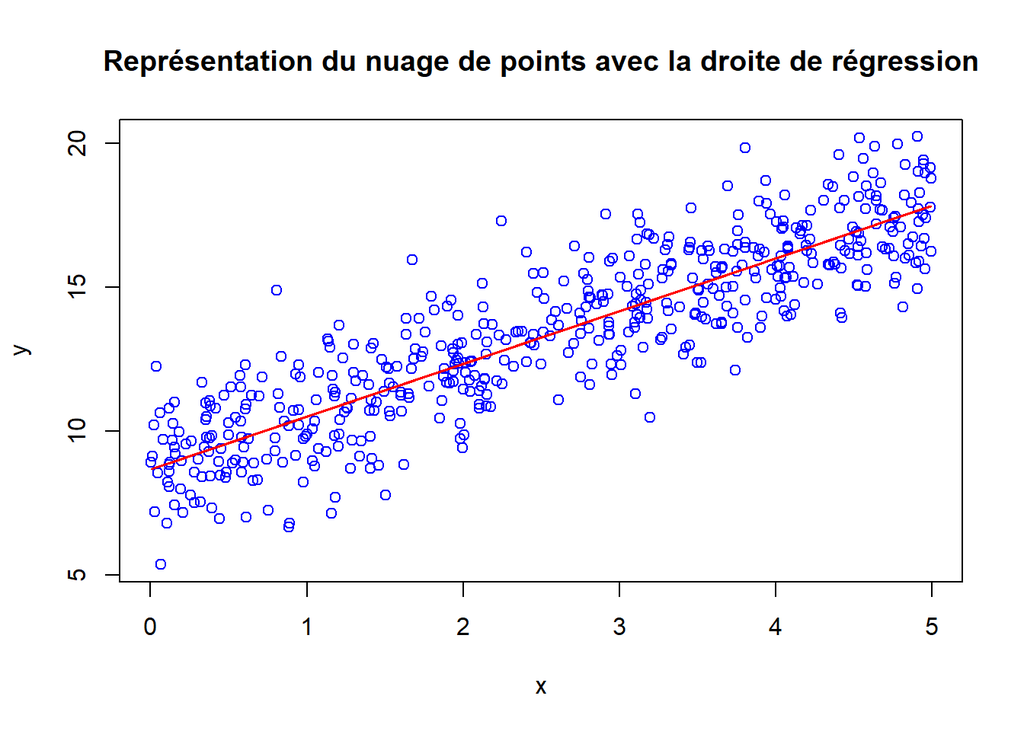

```r
# y en fonction de x (plot)
plot(x, y, col = "blue", main = "Représentation du nuage de points avec la droite de régression")
# b0*x + a0 (courbe)
lines(x, a0 + x*b0, add=TRUE, col = "red")
```

Nous observerons que le nuage de point $(x_i,y_i)_{1 \leq i \leq n}$ est concentré autour de la droite de régression $y=a+bx$.

- (Q3) Créer les functions “b_estim”, “a_estim”, “sigma_estim”, qui prennent en argument les couples $(x_i,y_i)_{1\leq i\leq n}$ de taille quelconque $n$ et qui renvoient l’estimation par les estimateurs sans biais des paramètres $b$, $a$ et $\sigma^2$.

```r
b_estim <- function(xy, n) {
  x <- xy[[1]]
  y <- xy[[2]]
  sxY <- mean(x*y)-mean(x)*mean(y)
  s2x <- mean((x - mean(x))**2)
  return(sxY/s2x)
}
a_estim <- function(xy, n) {
  x <- xy[[1]]
  y <- xy[[2]]
  b_est <- b_estim(xy, n)
  return(mean(y) - b_est*mean(x))
}
sigma_estim <- function(xy, n) {
  x <- xy[[1]]
  y <- xy[[2]]
  a_est <- a_estim(xy, n)
  b_est <- b_estim(xy, n)
  return(mean((y - a_est - b_est*x)**2))
}
```

- (Q4) A partir du jeu de données simulées aux questions (Q1a) et (Q1b), en déduire l’estimation de $a$, $b$ et $\sigma^2$.

1. Estimation de $a$ :

```r
# On crée la liste de couples
xy <- list(x,y)
a_est <- a_estim(xy, n)
a_est
```

```
## [1] 8.736369
```

2. Estimation de $b$ :

```r
b_est <- b_estim(xy, n)
b_est
```

```
## [1] 1.814336
```

3. Estimation de $\sigma^2$ :

```r
sigma_est <- sigma_estim(xy, n)
sigma_est
```

```
## [1] 2.135861
```

- (Q5) Représenter sur un même graphe, le nuage de points $(x_i,y_i)_{1\leq i \leq n}$ simulés en (Q1a) et (Q1b), la droite de régression $y=a_0 \; +\; b_0 \; x$ ainsi que la droite des moindres carrés (utiliser différentes couleurs sur le graphique pour distinguer ces deux droites).

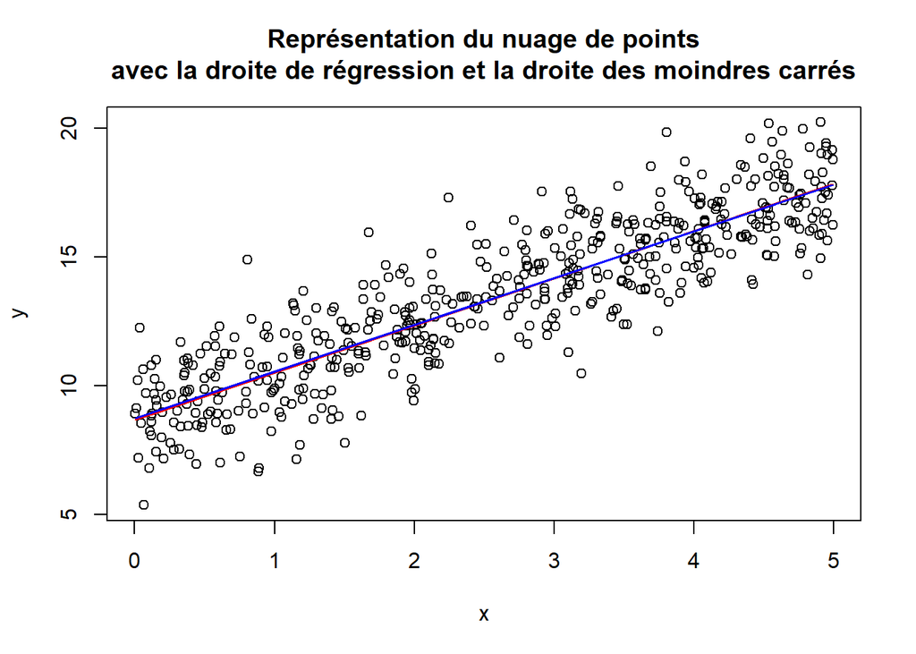

```r
plot(x, y, col="black", main = "Représentation du nuage de points\navec la droite de régression et la droite des moindres carrés")
lines(x, a0 + x*b0, add=TRUE, col="red")
y_ests <- a_est + b_est*x
lines(x, y_ests, add=TRUE, col="blue")
```

Après avoir représenté le nuage de points $(x_i,y_i)_{1\leq i \leq n}$ en noir, la droite de régression $y=a_0 \; +\; b_0 \; x$ en rouge, et la droite des moindres carrés $y = \hat a + \hat b x$ en bleu, nous remarquons que les deux droites suivent la même tendance que le nuage de points et qu’elles sont très proches. On en déduit que $\hat a \approx a0$ et que $\hat b \approx b$.

- (Q6) Déterminer le vecteur des résidus ${\hat \epsilon}_i$ et vérifier la propriété des résidus.

```r
# e_ests est le vecteur des résidus
e_ests <- y - y_ests
sum(e_ests)
```

```
## [1] 6.679102e-13
```

Nous commençons par calculer le vecteur des résidus $\hat \epsilon_i$ avec la formule donnée dans le formulaire. Nous stockons ce résultat dans la variable `e_ests`.

D’après la propriété des résidus, la somme des éléments contenus dans $\hat \epsilon_i$ devrait valoir zéro. Nous calculons cette somme et remarquons que $\displaystyle{\sum_{i=1}^n {\hat \epsilon}_i \approx 0}$. La propriété des résidus est respectée.

- (Q7) Vérifier que $({\bar x},{\bar y})$ appartient à la droite des moindres carrés.

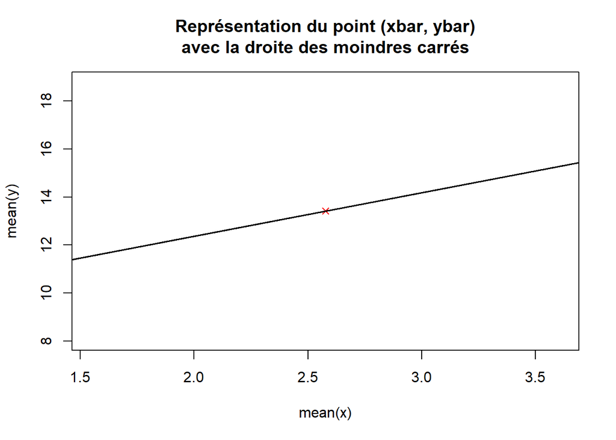

```r
# Le titre du graphique n'accepte pas les expressions latex, nous écrivons xbar et ybar
# à la place de l'écriture exacte
plot(mean(x), mean(y), col="red", pch=4, main = "Représentation du point (xbar, ybar)\navec la droite des moindres carrés")
lines(x, y_ests, col="black", add=TRUE)
```

Nous traçons la droite des moindres carrés en noir puis nous plaçons le point $(\bar x, \bar y)$ sous la forme d’une croix rouge. Visuellement, nous observons que le point $(\bar x, \bar y)$ appartient à la droite des moindres carrés, c’est-à-dire que $\bar y = \hat a + \hat b \bar x$. Cela confirme que la propriété des résidus est bien respectée.

- (Q8) En R, pour réaliser une régression linéaire on utilise la fonction `lm` (linear model) dont le premier argument est un objet R appelé une formule et qui spécifie une “sortie” et des “entrées” séparées par le signe `~`. Les entrées et sortie sont des noms de colonnes d’un `data.frame` qu’il faut spécifier en deuxième argument. Par exemple, si on veut réaliser la régression des données vary en fonction des données varx, on écrira

```r
donnees <- data.frame(varx = c(0, 0.2, 0.3, 0.6), vary = c(1.01, 1.44, 1.55, 2.1))
reg<-lm(vary~varx, data = donnees)
```

le résultat de la fonction `lm` est alors stocké dans l’objet `reg`; ce stockage est utile pour obtenir plus d’informations sur la régression effectuée, en appelant notamment la fonction `summary`: `summary(reg)`.

**Fournir les correspondances entre toutes les quantités déterminées aux questions précédentes et celles obtenues à partir de la variable “reg”.**

```r
donnees <- data.frame(varx = x, vary = y)
reg <- lm(vary~varx, data = donnees)
summary(reg)
```

```
##
## Call:
## lm(formula = vary ~ varx, data = donnees)
##
## Residuals:
##     Min      1Q  Median      3Q     Max
## -4.0508 -0.9699 -0.0352  0.9650  4.6765
##
## Coefficients:
##             Estimate Std. Error t value Pr(>|t|)
## (Intercept)  8.73637    0.12898   67.73   <2e-16 ***
## varx         1.81434    0.04334   41.87   <2e-16 ***
## ---
## Signif. codes:  0 '***' 0.001 '**' 0.01 '*' 0.05 '.' 0.1 ' ' 1
##
## Residual standard error: 1.464 on 513 degrees of freedom
## Multiple R-squared:  0.7736, Adjusted R-squared:  0.7732
## F-statistic:  1753 on 1 and 513 DF,  p-value: < 2.2e-16
```

Nous cherchons à comparer les résultats ci-dessus avec les résultats précédents.

1. La valeur `((Intercept), Estimate)` nous donne $\hat a$ d’après la fonction `lm`. Nous remarquons que cette valeur est la même que celle que nous avons trouvé plus tôt (Q4.1).

2. La valeur `((varx), Estimate)` nous donne $\hat b$ d’après la fonction `lm`. Nous remarquons que cette valeur est la même que celle que nous avons trouvé plus tôt (Q4.2).

3. La valeur `Residual standard error` nous donne $\hat \sigma$ d’après la fonction `lm`. Nous mettons cette valeur au carré pour trouver $\hat \sigma^2$.

```r
# Pour obtenir une estimation de sigma^2
summary(reg)$sigma**2
```

```
## [1] 2.144188
```

3(bis). La valeur de $\hat \sigma^2$ d’après la fonction `lm` se rapporche fortement de la valeur que nous avons trouvé à la question précédente (Q4.3).

- (Q9) En utilisant les fonctions `a_estim` et `b_estim`, illustrer graphiquement la convergence en probabilité de ${\hat a}$ et ${\hat b}$ vers $a=a_0$ et $b=b_0$ quand $n$ la taille de l’échantillon grandit.

```r
# Création d'un vecteur avec toutes les valeurs entre 2 et 1000
n = seq(2, 1000, by=1)
a_ests = c()
b_ests = c()
# Pour chaque valeur ni, on genère un échantillon de couples (x, y)
# puis on fait une estimation à partir de ce couple de a et b
for (ni in n) {
  x2 <- runif(ni, 0, 5)
  y2 <- generate_y(x2, a0, b0, s0)
  x2y2 <- list(x2, y2)
  a_ests = c(a_ests, a_estim(x2y2, ni))
  b_ests = c(b_ests, b_estim(x2y2, ni))
}
```

Nous génèrons 999 estimations de $a$ et $b$ pour différents couples $(x_i, y_i)_{1 \leq i \leq n}$ avec $n$ allant de 2 à 1000. Nous ne commençons pas i à 1, sinon on ne peut pas estimer les paramètres $a$ et $b$.

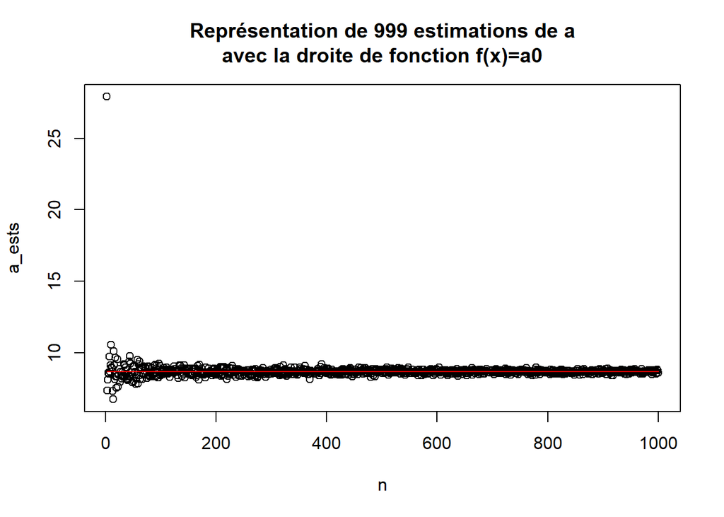

```r
plot(n, a_ests, col="black", main = "Représentation de 999 estimations de a\navec la droite de fonction f(x)=a0")
lines(n, n*0 + a0, col="red", add=TRUE)
```

Nous traçons un premier graphique de ${\hat a}$ en fonction de $n$ tout en traçant la fonction $f(x)=a=a_0$ pour montrer la convergence en probabilité de $\hat a$ vers $a=a_0$ quand $n$ grandit.

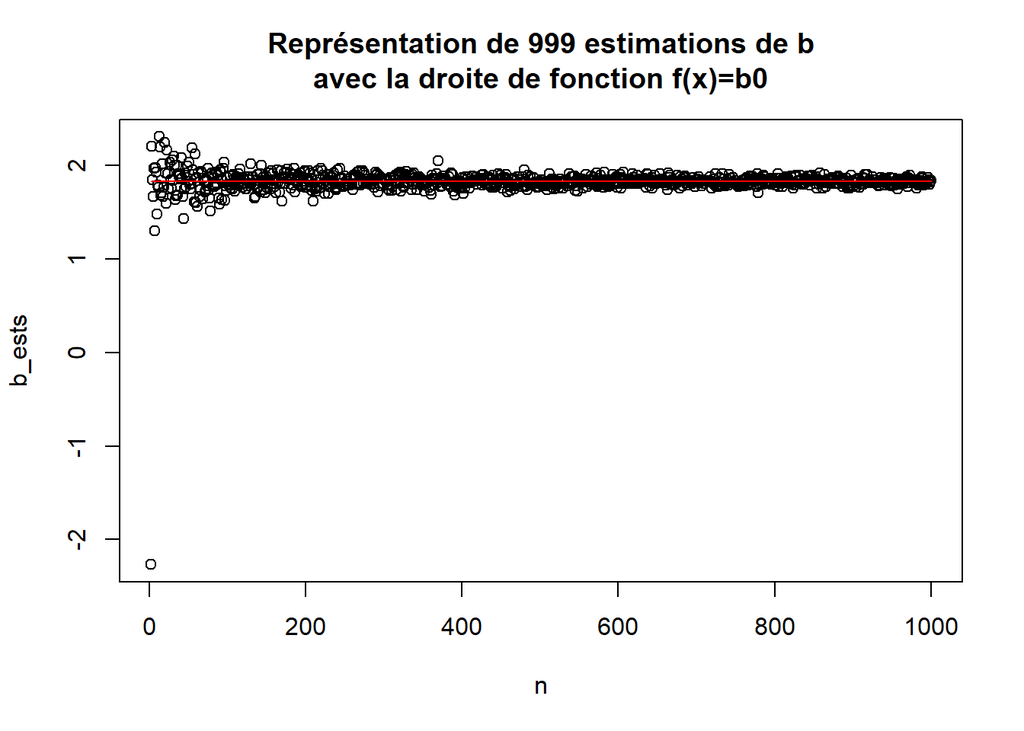

```r
plot(n, b_ests, col="black", main = "Représentation de 999 estimations de b\navec la droite de fonction f(x)=b0")
lines(n, n*0 + b0, col="red", add=TRUE)
```

Nous faisons de même mais pour ${\hat b}$ afin de montrer la convergence de $\hat b$ vers $b=b_0$ quand $n$ grandit.

Visuellement, nous observons bien que ${\hat a {\underset{n \rightarrow +\infty }{\overset{\mathbb{P}}{\longrightarrow}}} a}$ et que ${\hat b {\underset{n \rightarrow +\infty }{\overset{\mathbb{P}}{\longrightarrow}}} b}$ avec $a=a_0$ et $b=b_0$.

- (Q10) En utilisant les fonctions `replicate`, `a_estim`, et `b_estim`, illustrer le fait que
  $$\displaystyle{\frac{{\hat a} -
  a_0}{\displaystyle{\sqrt{\frac{{\hat \sigma}^2}{n}
  (1+\displaystyle{\frac{{\bar x}^2}{s_x^2}})}}}}\sim {\cal
  T}(n-2).$$
  *Indication :* Pour un $n$ choisi,
1. simuler $150$ réalisations de $n$ couples $(x_{i,t},y_{i,t})_{ 1 \leq i \leq n}$, $1\leq t\leq 150$
2. pour tout $t =1,\ldots,150$, déterminer ${\hat a}_t$ à partir du n-uplet $(x_{i,t},y_{i,t})_{ 1 \leq i \leq n}$
3. représenter sur un même graphique la densité d’une loi de Student à $(n-2)$ degrès de liberté ainsi que l’histogramme de
   $$(\frac{{\hat a}_t -
   a_0}{\displaystyle{\sqrt{\frac{{\hat \sigma}_t^2}{n}
   (1+\displaystyle{\frac{{\bar x}_t^2}{s_{x,t}^2}})}}})_{1\leq t \leq
   150}.$$

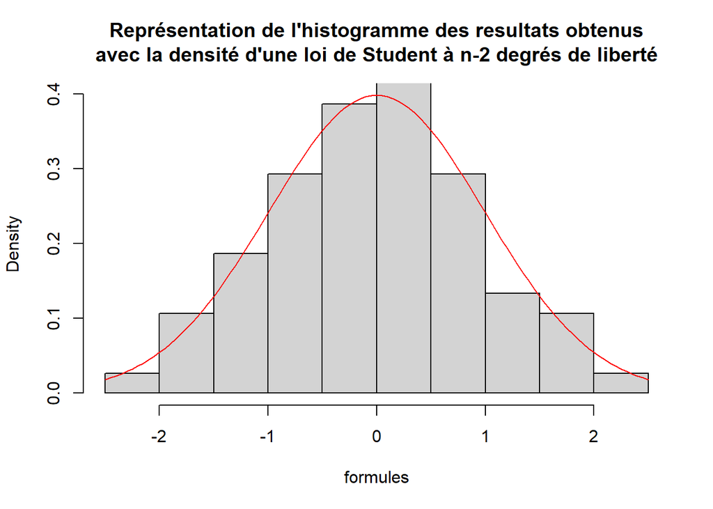

```r
# Fonction générant un couple xy
gen_couple_xy <- function(n) {
  x <- runif(n, 0, 5)
  y <- generate_y(x, a0, b0, s0)
  return(list(x,y))
}
# Fonction générant un couple xy de taille n
# et renvoyant la valeur trouvée par la formule
calcul_formule <- function(n) {
  xy <- gen_couple_xy(n)
  x <- xy[[1]]
  y <- xy[[2]]
  a_est <- a_estim(xy, n)
  b_est <- b_estim(xy, n)
  s2xt <- mean((y - mean(y))*(x - mean(x)))/b_est
  sigma_est <- sigma_estim(xy, n)
  # Calcul avec la formule donnée
  res <- (a_est - a0)/sqrt((sigma_est/n)*(1+((mean(x)**2)/s2xt)))
  return(res)
}
n <- 200
# Nous réalisons 150 réalisations de notre calcul pour n=200
formules <- replicate(150, calcul_formule(n))
# Nous traçons l'historgramme des 150 formules obtenues
# et la densité d'une loi de Student à n-2 degrés de liberté
hist(formules, prob = TRUE, ylim = c(0, max(dt(x, df=n-2))), main = "Représentation de l'histogramme des resultats obtenus\navec la densité d'une loi de Student à n-2 degrés de liberté")
curve(dt(x, df=n-2), col="red", add=TRUE)
```

Nous remarquons que la cloche formée par l’histogramme suit graphiquement le même parcours de la loi de Student à n-2 degrés de liberté. Nous pouvons en déduire que :
$$\displaystyle{\frac{{\hat a}
- a_0}{\displaystyle{\sqrt{\frac{{\hat \sigma}^2}{n}
(1+\displaystyle{\frac{{\bar x}^2}{s_x^2}})}}}}\sim {\cal
T}(n-2).$$

- (Q11) Créer les fonctions `gen_IC_a`, `gen_IC_b` et `gen_IC_s` qui prennent en argument le vecteur des observations $(x_i,y_i)_{1\leq i \leq n}$ de taille quelconque $n$ et un niveau de confiance $1-\alpha$ et renvoient un intervalle de confiance bilatéral pour $a$, $b$ et $\sigma^2$ sous forme d’un vecteur de longueur $2$ contenant la borne inférieure et la borne supérieure.

```r
gen_IC_a <- function(xy, nv_confiance) {
  alpha <- 1 - nv_confiance
  x <- unlist(xy[1])
  y <- unlist(xy[2])
  n <- length(x)
  a_est <- a_estim(xy, n)
  b_est <- b_estim(xy, n)
  s2x <- mean((y - mean(y))*(x - mean(x)))/b_est
  a_IC <- a_est + c(-1,1) * qt(1 - (alpha/2), df=n-2) * sqrt((sigma_est/n) * (1+((mean(x)**2)/s2x)))
  return(a_IC)
}
gen_IC_b <- function (xy, nv_confiance) {
  alpha <- 1 - nv_confiance
  x <- unlist(xy[1])
  y <- unlist(xy[2])
  n <- length(x)
  sigma_est <- sigma_estim(xy, n)
  b_est <- b_estim(xy, n)
  s2x <- mean((y - mean(y))*(x - mean(x)))/b_est
  b_IC <- b_est + c(-1, 1) * qt(1 - (alpha/2), df=n-2) * sqrt(sigma_est/(n*s2x))
  return(b_IC)
}
gen_IC_s <- function(xy, nv_confiance) {
  alpha <- 1 - nv_confiance
  x <- unlist(xy[1])
  y <- unlist(xy[2])
  n <- length(x)
  chi2_quantiles <- c(qchisq(1 - alpha/2, df = n-2), qchisq(alpha/2, df = n-2))
  sigma_est <- sigma_estim(xy, n)
  s_IC <- ((n-2) * sigma_est) / chi2_quantiles
  return(s_IC)
}
```

- (Q12) En utilisant la fonction “replicate”, créer $100$ intervalles de confiance pour $a$, $b$ et $\sigma^2$.

```r
alpha <- 0.05
n <- 1000
a_IC_100 <- replicate(n, gen_IC_a(gen_couple_xy(100), 1-alpha))
b_IC_100 <- replicate(n, gen_IC_b(gen_couple_xy(100), 1-alpha))
s_IC_100 <- replicate(n, gen_IC_s(gen_couple_xy(100), 1-alpha))
```

Nous avons décidé de prendre un niveau de confiance de 95% (d’où $\alpha = 0.05$). Nous devrions trouver qu’environ 95% des intervalles de confiance générés encadrent la variable estimée.

- (Q13) Pour visualiser les intervalles de confiance, la fonction `plot_ICs` est disponible dans le fichier `utils.R` à télécharger sous moodle et à sourcer par la commande `source("Utils.R")`. Visualiser les intervalles de confiance de la question (Q12) et commenter les résultats.

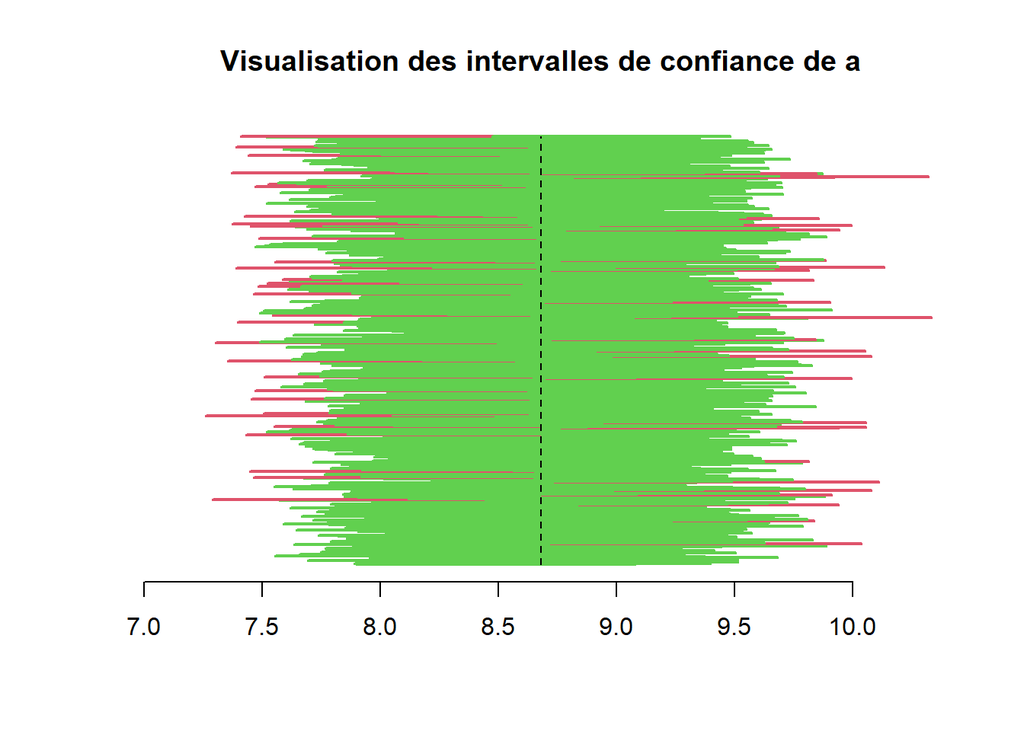

```r
source("Utils.R")
plot_ICs(a_IC_100, a0, main = "Visualisation des intervalles de confiance de a")
```

```r
# Nous permet de visualiser la proportion d'intervalles de confiance justes
hit <- a_IC_100[1, ] < a0 & a_IC_100[2, ] > a0
sum(hit)/length(hit)
```

```
## [1] 0.943
```

Nous remarquons que l’écrasante majorité des intervalles de confiance générés pour $a$ sont corrects et encadrent bien $a_0$.

Le rapport que nous avons décidé de calculer ensuite nous permet de confirmer que nous avons aux alentours de 95% d’intervalles de confiance corrects pour $a$.

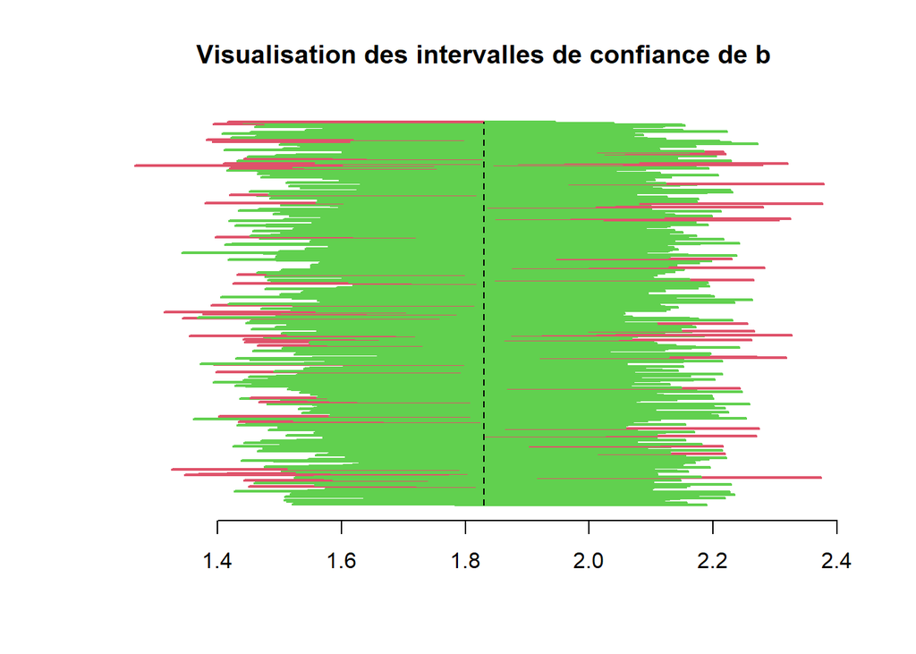

```r
plot_ICs(b_IC_100, b0, main = "Visualisation des intervalles de confiance de b")
```

```r
# Nous permet de visualiser la proportion d'intervalles de confiance justes
hit <- b_IC_100[1, ] < b0 & b_IC_100[2, ] > b0
sum(hit)/length(hit)
```

```
## [1] 0.942
```

Nous remarquons que l’écrasante majorité des intervalles de confiance générés pour $b$ sont corrects et encadrent bien $b_0$.

Le rapport que nous avons décidé de calculer ensuite nous permet de confirmer que nous avons aux alentours de 95% d’intervalles de confiance corrects pour $b$.

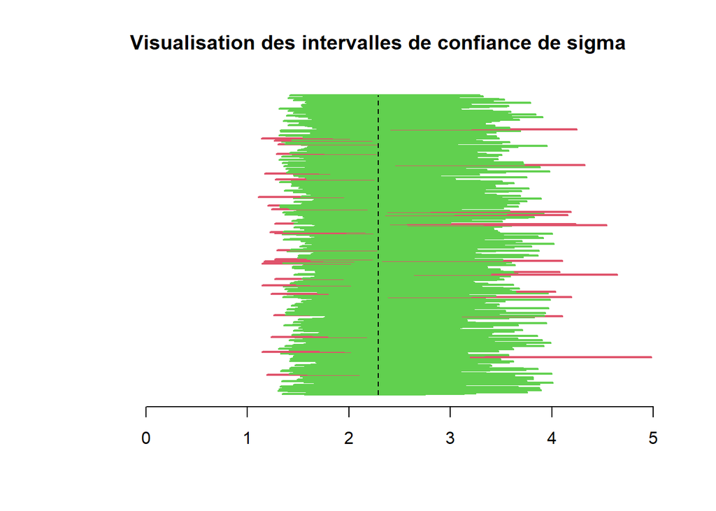

```r
plot_ICs(s_IC_100, s0, main = "Visualisation des intervalles de confiance de sigma")
```

```r
# Nous permet de visualiser la proportion d'intervalles de confiance justes
hit <- s_IC_100[1, ] < s0 & s_IC_100[2, ] > s0
sum(hit)/length(hit)
```

```
## [1] 0.964
```

Nous remarquons que l’écrasante majorité des intervalles de confiance générés pour $\sigma^2$ sont corrects et encadrent bien $\sigma^2_0$.

Le rapport que nous avons décidé de calculer ensuite nous permet de confirmer que nous avons aux alentours de 95% d’intervalles de confiance corrects pour $\sigma^2$.

# Homoscédasticité, indépendance et normalité des résidus

Le coefficient de détermination est insuffisant pour rendre compte de la qualité de l’ajustement. À titre d’exemple, on utilise le jeu de données d’Anscombe qui consiste en 4 ensembles de 11 points du plan.

Sous l’hypothèse d’homoscédasticité, d’indépendance et de normalité des erreurs, les résidus sont indépendants (mais non identiquement distribués) de loi normale centrée mais de variance qui dépend de l’indice $i$; on préfère alors considérer les résidus corrigés qui sont iid de loi normale centrée et de variance égale à $\sigma^2$. Les résidus corrigés $\tilde{\epsilon_i}$ sont définis par
$$\tilde{\epsilon_i} =
\frac{\hat{\epsilon}_i}{\sqrt{1-h_i}}, \quad \text{avec}\; h_i =
\frac{1}{n}+ \frac{(x_i-\bar{x})^2}{\sum_{j=1}^{n}(x_j
-\bar{x})^2},\quad i=1,\ldots,n.$$

- (Q14) Representer les 4 jeux de données inclus dans Anscombe.

Import du jeu de données anscombe.

```r
data(anscombe)
knitr::kable(anscombe, caption = "Données d'Anscombe")
```

Données d’Anscombe

| x1 | x2 | x3 | x4 | y1 | y2 | y3 | y4 |
| --- | --- | --- | --- | --- | --- | --- | --- |
| 10 | 10 | 10 | 8 | 8.04 | 9.14 | 7.46 | 6.58 |
| 8 | 8 | 8 | 8 | 6.95 | 8.14 | 6.77 | 5.76 |
| 13 | 13 | 13 | 8 | 7.58 | 8.74 | 12.74 | 7.71 |
| 9 | 9 | 9 | 8 | 8.81 | 8.77 | 7.11 | 8.84 |
| 11 | 11 | 11 | 8 | 8.33 | 9.26 | 7.81 | 8.47 |
| 14 | 14 | 14 | 8 | 9.96 | 8.10 | 8.84 | 7.04 |
| 6 | 6 | 6 | 8 | 7.24 | 6.13 | 6.08 | 5.25 |
| 4 | 4 | 4 | 19 | 4.26 | 3.10 | 5.39 | 12.50 |
| 12 | 12 | 12 | 8 | 10.84 | 9.13 | 8.15 | 5.56 |
| 7 | 7 | 7 | 8 | 4.82 | 7.26 | 6.42 | 7.91 |
| 5 | 5 | 5 | 8 | 5.68 | 4.74 | 5.73 | 6.89 |

```r
# Affichage des 4 jeux de données Anscombe
knitr::kable(anscombe[, c("x1", "y1")], caption = "Données d'Anscombe1")
```

Données d’Anscombe1

| x1 | y1 |
| --- | --- |
| 10 | 8.04 |
| 8 | 6.95 |
| 13 | 7.58 |
| 9 | 8.81 |
| 11 | 8.33 |
| 14 | 9.96 |
| 6 | 7.24 |
| 4 | 4.26 |
| 12 | 10.84 |
| 7 | 4.82 |
| 5 | 5.68 |

```r
knitr::kable(anscombe[, c("x2", "y2")], caption = "Données d'Anscombe2")
```

Données d’Anscombe2

| x2 | y2 |
| --- | --- |
| 10 | 9.14 |
| 8 | 8.14 |
| 13 | 8.74 |
| 9 | 8.77 |
| 11 | 9.26 |
| 14 | 8.10 |
| 6 | 6.13 |
| 4 | 3.10 |
| 12 | 9.13 |
| 7 | 7.26 |
| 5 | 4.74 |

```r
knitr::kable(anscombe[, c("x3", "y3")], caption = "Données d'Anscombe3")
```

Données d’Anscombe3

| x3 | y3 |
| --- | --- |
| 10 | 7.46 |
| 8 | 6.77 |
| 13 | 12.74 |
| 9 | 7.11 |
| 11 | 7.81 |
| 14 | 8.84 |
| 6 | 6.08 |
| 4 | 5.39 |
| 12 | 8.15 |
| 7 | 6.42 |
| 5 | 5.73 |

```r
knitr::kable(anscombe[, c("x4", "y4")], caption = "Données d'Anscombe4")
```

Données d’Anscombe4

| x4 | y4 |
| --- | --- |
| 8 | 6.58 |
| 8 | 5.76 |
| 8 | 7.71 |
| 8 | 8.84 |
| 8 | 8.47 |
| 8 | 7.04 |
| 8 | 5.25 |
| 19 | 12.50 |
| 8 | 5.56 |
| 8 | 7.91 |
| 8 | 6.89 |

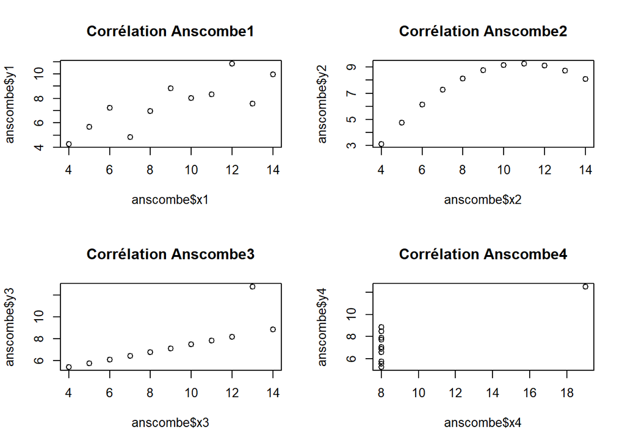

```r
# Génération des graphiques de corrélation
par(mfrow = c(2,2))

plot(anscombe$x1, anscombe$y1, main = "Corrélation Anscombe1")
plot(anscombe$x2, anscombe$y2, main = "Corrélation Anscombe2")
plot(anscombe$x3, anscombe$y3, main = "Corrélation Anscombe3")
plot(anscombe$x4, anscombe$y4, main = "Corrélation Anscombe4")
```

- (Q15) Effectuer les régressions linéaires sur les 4 ensembles de points. Discuter des résultats obtenus.

Nous appliquons la régression linéaire sur les 4 jeux de données.

```r
# Application de la régression linéaire sur les 4 jeux de données
reg1<-lm(anscombe$y1~anscombe$x1)
reg2<-lm(anscombe$y2~anscombe$x2)
reg3<-lm(anscombe$y3~anscombe$x3)
reg4<-lm(anscombe$y4~anscombe$x4)
```

Nous affichons les résumés statistiques des régressions linéaires sur les quatre jeux de données afin d’identifier les éléments statistiques qui nous intéressent.

```r
summary(reg1)
```

```
##
## Call:
## lm(formula = anscombe$y1 ~ anscombe$x1)
##
## Residuals:
##      Min       1Q   Median       3Q      Max
## -1.92127 -0.45577 -0.04136  0.70941  1.83882
##
## Coefficients:
##             Estimate Std. Error t value Pr(>|t|)
## (Intercept)   3.0001     1.1247   2.667  0.02573 *
## anscombe$x1   0.5001     0.1179   4.241  0.00217 **
## ---
## Signif. codes:  0 '***' 0.001 '**' 0.01 '*' 0.05 '.' 0.1 ' ' 1
##
## Residual standard error: 1.237 on 9 degrees of freedom
## Multiple R-squared:  0.6665, Adjusted R-squared:  0.6295
## F-statistic: 17.99 on 1 and 9 DF,  p-value: 0.00217
```

```r
summary(reg2)
```

```
##
## Call:
## lm(formula = anscombe$y2 ~ anscombe$x2)
##
## Residuals:
##     Min      1Q  Median      3Q     Max
## -1.9009 -0.7609  0.1291  0.9491  1.2691
##
## Coefficients:
##             Estimate Std. Error t value Pr(>|t|)
## (Intercept)    3.001      1.125   2.667  0.02576 *
## anscombe$x2    0.500      0.118   4.239  0.00218 **
## ---
## Signif. codes:  0 '***' 0.001 '**' 0.01 '*' 0.05 '.' 0.1 ' ' 1
##
## Residual standard error: 1.237 on 9 degrees of freedom
## Multiple R-squared:  0.6662, Adjusted R-squared:  0.6292
## F-statistic: 17.97 on 1 and 9 DF,  p-value: 0.002179
```

```r
summary(reg3)
```

```
##
## Call:
## lm(formula = anscombe$y3 ~ anscombe$x3)
##
## Residuals:
##     Min      1Q  Median      3Q     Max
## -1.1586 -0.6146 -0.2303  0.1540  3.2411
##
## Coefficients:
##             Estimate Std. Error t value Pr(>|t|)
## (Intercept)   3.0025     1.1245   2.670  0.02562 *
## anscombe$x3   0.4997     0.1179   4.239  0.00218 **
## ---
## Signif. codes:  0 '***' 0.001 '**' 0.01 '*' 0.05 '.' 0.1 ' ' 1
##
## Residual standard error: 1.236 on 9 degrees of freedom
## Multiple R-squared:  0.6663, Adjusted R-squared:  0.6292
## F-statistic: 17.97 on 1 and 9 DF,  p-value: 0.002176
```

```r
summary(reg4)
```

```
##
## Call:
## lm(formula = anscombe$y4 ~ anscombe$x4)
##
## Residuals:
##    Min     1Q Median     3Q    Max
## -1.751 -0.831  0.000  0.809  1.839
##
## Coefficients:
##             Estimate Std. Error t value Pr(>|t|)
## (Intercept)   3.0017     1.1239   2.671  0.02559 *
## anscombe$x4   0.4999     0.1178   4.243  0.00216 **
## ---
## Signif. codes:  0 '***' 0.001 '**' 0.01 '*' 0.05 '.' 0.1 ' ' 1
##
## Residual standard error: 1.236 on 9 degrees of freedom
## Multiple R-squared:  0.6667, Adjusted R-squared:  0.6297
## F-statistic:    18 on 1 and 9 DF,  p-value: 0.002165
```

Nous nous intéressons aux coefficients $\hat a$ et $\hat b$, ainsi qu’au $\hat \sigma^2$.

```r
# Anscombe1
reg1$coefficient
```

```
## (Intercept) anscombe$x1
##   3.0000909   0.5000909
```

```r
summary(reg1)$sigma**2
```

```
## [1] 1.529188
```

Pour Anscombe1, $\hat b_1 \approx 0.5$ , $\hat a_1 \approx 3.0$ et $\hat \sigma_1^2 \approx 1.53$.

```r
# Anscombe2
reg2$coefficient
```

```
## (Intercept) anscombe$x2
##    3.000909    0.500000
```

```r
summary(reg2)$sigma**2
```

```
## [1] 1.530699
```

Pour Anscombe2, $\hat b_2 \approx 0.5$ , $\hat a_2 \approx 3.0$ et $\hat \sigma_2^2 \approx 1.53$.

```r
# Anscombe3
reg3$coefficient
```

```
## (Intercept) anscombe$x3
##   3.0024545   0.4997273
```

```r
summary(reg3)$sigma**2
```

```
## [1] 1.528466
```

Pour Anscombe3, $\hat b_3 \approx 0.5$ , $\hat a_3 \approx 3.0$ et $\hat \sigma_3^2 \approx 1.53$.

```r
# Anscombe4
reg4$coefficient
```

```
## (Intercept) anscombe$x4
##   3.0017273   0.4999091
```

```r
summary(reg4)$sigma**2
```

```
## [1] 1.526943
```

Pour Anscombe4, $\hat b_3 \approx 0.5$ , $\hat a_3 \approx 3.0$ et $\hat \sigma_3^2 \approx 1.53$.

Nous traçons les graphiques de corrélation et les enrichissons avec la droite de régression de chaque sous-jeu de données.

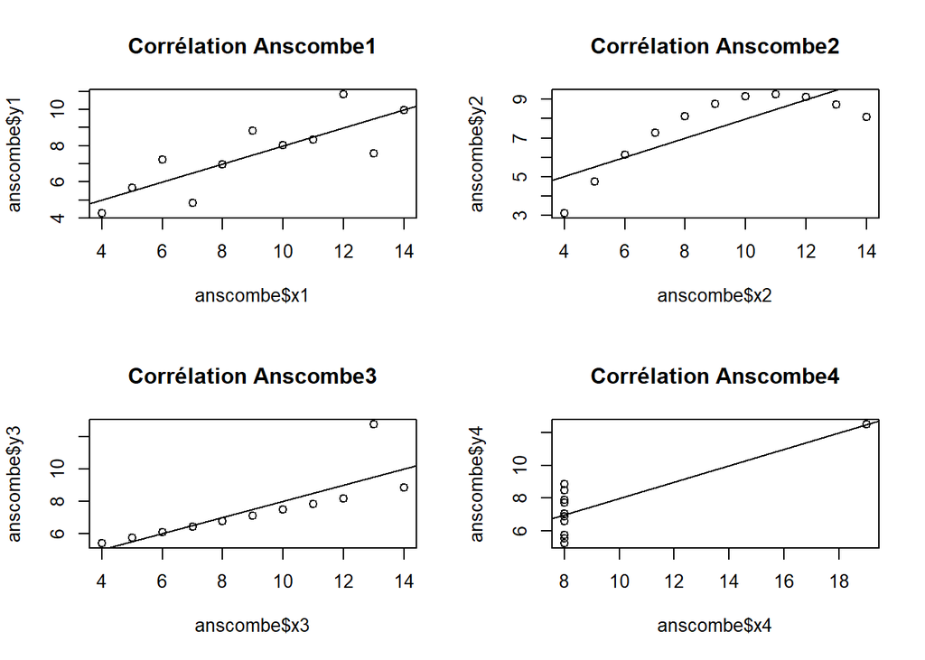

```r
# Génération des graphiques de corrélation avec leur droite de régression
par(mfrow = c(2,2))

plot(anscombe$x1, anscombe$y1, main = "Corrélation Anscombe1")
abline(reg1)

plot(anscombe$x2, anscombe$y2, main = "Corrélation Anscombe2")
abline(reg2)

plot(anscombe$x3, anscombe$y3, main = "Corrélation Anscombe3")
abline(reg3)

plot(anscombe$x4, anscombe$y4, main = "Corrélation Anscombe4")
abline(reg4)
```

Nous remarquons que les droites de régressions ont les mêmes équations $\hat y_i = \hat a_i + \hat b_ix \approx 3 + 0.5x$ avec $1 \leq i \leq 4$. Il est intéressant de noter que les nuages de points sont très différents entre eux mais ont la même droite de régression.

- (Q16) Pour estimer la qualité de l’ajustement, on utilise quelques diagnostics graphiques qui permettent de vérifier empiriquement la validité des hypothèses $(\mathcal{ H})$ (cf section 7.5 du poly de cours).

  Faire une analyse des résidus et discuter de la validité des hypothèses de normalité, d’homoscédasticité et éventuellement des hypothèses de linéarité et d’indépendance pour l’ensemble des régressions linéaires proposées par le jeu de données Anscombe.

  En particulier, on tracera
  - Pour la normalité, le diagramme quantile–quantile des résidus avec les fonctions `qqnorm` et `qqline` (on pourra également tracer l’histogramme des résidus corrigés et y superposer la densité d’une normale d’espérance leur moyenne empirique et d’écart-type, leur écart-type empirique);

```r
# Calcul des résidus
residuals1 <- residuals(reg1)
residuals2 <- residuals(reg2)
residuals3 <- residuals(reg3)
residuals4 <- residuals(reg4)
```

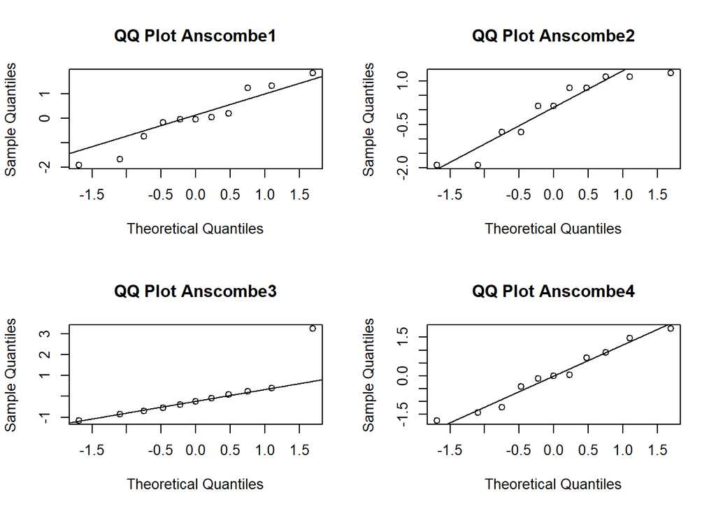

```r
# Génération des diagrammes Quantile-Quantile
par(mfrow = c(2,2))

qqnorm(residuals1, main = "QQ Plot Anscombe1")
qqline(residuals1)
qqnorm(residuals2, main = "QQ Plot Anscombe2")
qqline(residuals2)
qqnorm(residuals3, main = "QQ Plot Anscombe3")
qqline(residuals3)
qqnorm(residuals4, main = "QQ Plot Anscombe4")
qqline(residuals4)
```

Ces diagrammes Quantile-Quantile nous permettent de comparer la distribution des données en comparaison à la distribution normale.

Nous observons que les données des 4 jeux de données suivent plus ou moins la distribution normale. Cependant, nous remarquons que l’une des observations dans Anscombe3 constitue une valeur aberrante et que les observations d’Anscombe1 sont parfois un peu plus éloignées de la distribution normale même si la tendance semble correcte.

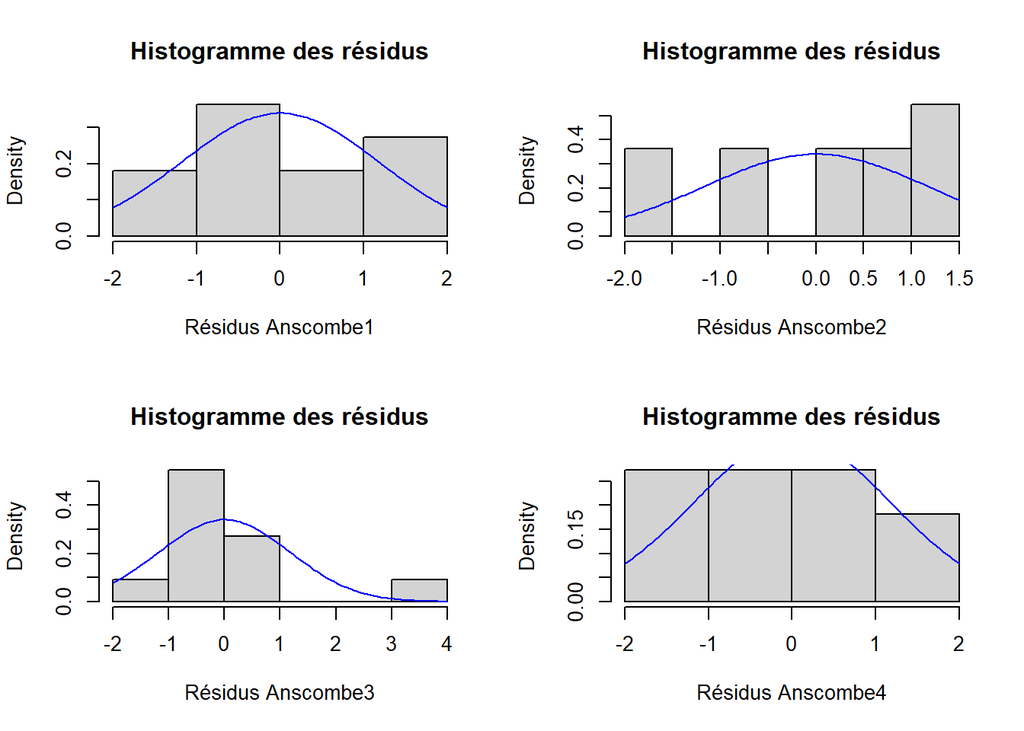

```r
# Génération des histogrammes des résidus corrigés et densité de la normale
par(mfrow = c(2,2))
hist(residuals1, prob= TRUE, main="Histogramme des résidus", xlab="Résidus Anscombe1")
curve(dnorm(x, mean=mean(residuals1), sd=sd(residuals1)), add=TRUE, col="blue")

hist(residuals2, prob= TRUE, main="Histogramme des résidus", xlab="Résidus Anscombe2")
curve(dnorm(x, mean=mean(residuals2), sd=sd(residuals2)), add=TRUE, col="blue")

hist(residuals3, prob= TRUE, main="Histogramme des résidus", xlab="Résidus Anscombe3")
curve(dnorm(x, mean=mean(residuals3), sd=sd(residuals3)), add=TRUE, col="blue")

hist(residuals4, prob= TRUE, main="Histogramme des résidus", xlab="Résidus Anscombe4")
curve(dnorm(x, mean=mean(residuals4), sd=sd(residuals4)), add=TRUE, col="blue")
```

```r
# Tests de Shapiro-Wilk
shapiro.test(residuals1)
```

```
##
##  Shapiro-Wilk normality test
##
## data:  residuals1
## W = 0.94211, p-value = 0.5456
```

```r
shapiro.test(residuals2)
```

```
##
##  Shapiro-Wilk normality test
##
## data:  residuals2
## W = 0.87615, p-value = 0.09295
```

```r
shapiro.test(residuals3)
```

```
##
##  Shapiro-Wilk normality test
##
## data:  residuals3
## W = 0.74073, p-value = 0.001574
```

```r
shapiro.test(residuals4)
```

```
##
##  Shapiro-Wilk normality test
##
## data:  residuals4
## W = 0.96067, p-value = 0.78
```

Enfin, pour appuyer les précédentes observations faites sur la normalité, nous utilisons le test de Shapiro-Wilk. Les hypothèses de ce test sont les suivantes :

$H_0$ : la variable est normalement distribuée

$H_1$ : la variable n’est pas normalement distribuée

Plus la statistique $W$ se rapproche de 1, plus l’hypothèse de normalité est pertinente pour le jeu de données. Anscombe4 et Anscombe1 ont un $W > 0.94$ ce qui indique qu’ils se rapprochent fortement d’une loi normale et Anscombe2 a un $W \approx 0.87$ donc qui se rapproche (un peu moins) d’une loi normale.

Aussi, pour un risque à $0.05$, la p-value nous amène à retenir Anscombe1, Anscombe2 et Anscombe4 normalement distribués car leur p-value est strictement supérieure au risque $0.05$.

```
-   Pour l'homoscédasticité et éventuellement l'indépendance, les résidus standardisés (`rstandard`) en fonction des prédictions (`fitted.values`) ou bien en fonction des valeurs de la variable explicative.
```

```r
# Calcul des résidus standardisés
residuals_standardized1 <- rstandard(reg1)
residuals_standardized2 <- rstandard(reg2)
residuals_standardized3 <- rstandard(reg3)
residuals_standardized4 <- rstandard(reg4)
```

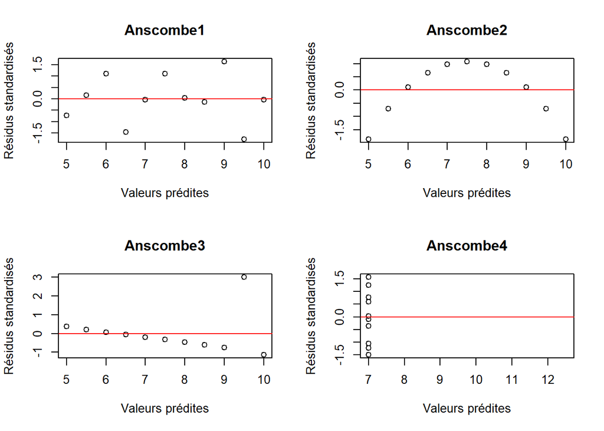

```r
# Génération des graphiques des résidus standardisés en fonctions des prédictions
par(mfrow = c(2,2))

plot(fitted.values(reg1), residuals_standardized1, main="Anscombe1", xlab="Valeurs prédites", ylab="Résidus standardisés")
abline(h=0, col="red")

plot(fitted.values(reg2), residuals_standardized2, main="Anscombe2", xlab="Valeurs prédites", ylab="Résidus standardisés")
abline(h=0, col="red")

plot(fitted.values(reg3), residuals_standardized3, main="Anscombe3", xlab="Valeurs prédites", ylab="Résidus standardisés")
abline(h=0, col="red")

plot(fitted.values(reg4), residuals_standardized4, main="Anscombe4", xlab="Valeurs prédites", ylab="Résidus standardisés")
abline(h=0, col="red")
```

Seul Anscombe1 valide l’hypothèse d’homoscédasticité car nous n’observons pas de variation selon x dans la dispersion.

Au contraire, pour Anscombe2 les résidus standardisés en fonction de l’abscisse des données semblent suivre une relation quadratique.

Pour Anscombe3, nous n’observons pas de caractère aléatoire et cela semble suivre une fonction.

Pour Anscombe4, nous sommes étonnés de ne plus trouver sur ce graphique la valeur aberrante qui se détachait précédemment sur la représentation de ce jeu de données. En ne prenant pas en considération cette valeur aberrante, Anscombe4 valide l’hypothèse d’homoscédasticité. Mais si nous prenons en compte la valeur aberrante, Anscombe4 ne valide pas l’hypothèse d’homoscédasticité.

En effet, nous remarquons que le graphique des résidus (non standardisés) en fonction des prédictions est différent que celui présenté ci-dessus.

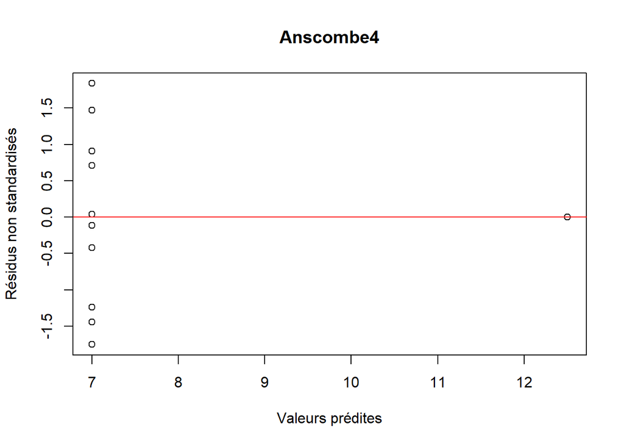

```r
plot(fitted(reg4), residuals4, main="Anscombe4", xlab="Valeurs prédites", ylab="Résidus non standardisés")
abline(h=0, col="red")
```

En conclusion :

Anscombe1 valide les hypothèses de normalité et d’homoscédasticité.

Anscombe2 valide l’hypothèse de normalité (de peu).

Anscombe3 ne valide aucune des deux hypothèses explorées.

Anscombe4 valide l’hypothèse de normalité et d’homoscédasticité (pour les résidus standardisés).

# Jeu de données réelles `Real_Data`

- Choisir un jeu de données $(x_i,y_i)_i$ dans l’un des trois fichiers proposés `car.csv` ou `bodyfat.dat` ou `happiness.csv` ou choisir un jeu de données qui vous est propre :
  - si vous optez pour l’un des jeu de données proposés, alors vous choisirez un jeu de données qui vous parait cohérent de modéliser par le modèle de régression linéaire et vous décrirez votre démarche dans la question 14; en particulier, avant de retenir une paire de variables qui convient, vous étudierez les possibilités de modèles possibles de régression pour différentes paires de variables numériques du data.frame.
  - Si vous optez pour un jeu de données qui vous est propre, alors demandez l’avis au responsable de l’uv avant de traiter la suite.
  - Charger le jeu de données `Real_Data`

## Quelques éléments de statistique descriptive

- (Q17) Motiver le choix de votre jeu de données par des éléments de statistique descriptive qui vous font penser que la modélisation de ce jeu de données par un modèle de régression linéaire parait judicieux (représentation graphique, coefficient de corrélation,…, ..)

Nous choisissons d’utiliser le jeu de données `bodyfat.dat`, en particulier les colonnes `Fat`et `Triceps`. Ayant quelques soucis lors de l’utilisation du fichier en format `.dat` nous l’avons converti en `.csv` à l’aide d’un script python.

Nous avons sélectionné ce jeu de données et plus particulièrement ces variables car, intuitivement, elles nous paraissent avoir un lien entre elles. La variable `Fat` représente la masse graisseuse d’un invidu et la variable `Triceps` représente l’épaisseur du pli cutané du triceps. L’échantillon du jeu de données a été prélevé sur 20 femmes en bonne santé agées entre 20 et 30 ans.

Ci-dessous, nous avons représenté graphiquement trois paires de données : `Fat` expliquée par `Triceps`, `Fat` expliquée par `Thigh` et `Fat` expliquée par `Midarm`.

```r
bodyfat <- read.csv('Jeux_Donnees/bodyfat.csv')
```

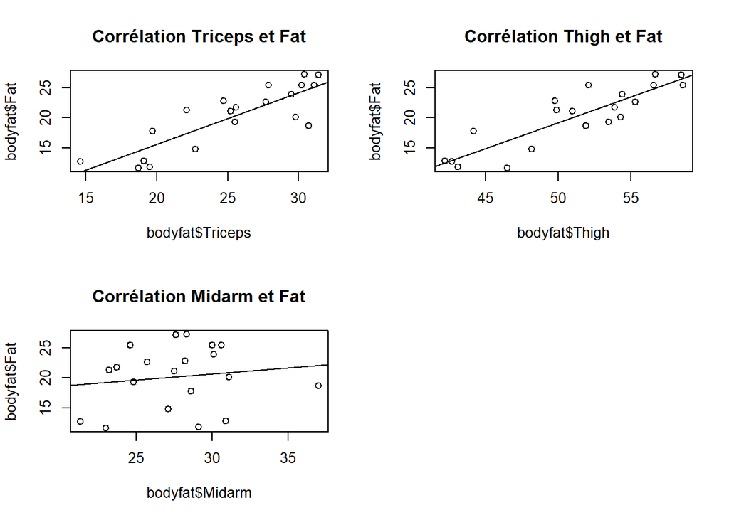

```r
par(mfrow = c(2,2))

regTriceps<-lm(bodyfat$Fat~bodyfat$Triceps)
regThigh<-lm(bodyfat$Fat~bodyfat$Thigh)
regMidarm<-lm(bodyfat$Fat~bodyfat$Midarm)

plot(bodyfat$Triceps, bodyfat$Fat, main = "Corrélation Triceps et Fat")
abline(regTriceps)
plot(bodyfat$Thigh, bodyfat$Fat, main = "Corrélation Thigh et Fat")
abline(regThigh)
plot(bodyfat$Midarm, bodyfat$Fat, main = "Corrélation Midarm et Fat")
abline(regMidarm)
```

Nous observons une tendance linéaire entre les variables `Fat` et `Triceps` qui témoigne d’une possible corrélation entre elles ainsi qu’entre `Fat` et `Thigh`. Cependant, nous n’observons pas de corrélation entre les variables `Fat` et `Midarm`. Notre choix se fait en faveur de `Triceps` car nous pensons qu’il est plus intéressant d’étudier la corrélation avec l’épaisseur du pli cutané du triceps plutôt qu’avec le tour de cuisse.

```r
Real_Data <- read.csv('Jeux_Donnees/bodyfat.csv')
```

## Estimation ponctuelle et par IC des paramètres

- (Q18) Estimer les paramètres du modèle de régression, tracer sur un graphique le nuage de points ainsi que la droite des moindres carrés et discuter de la pertinence de votre choix de modèle.

Dans la suite du projet, nous travaillons avec `Fat` la variable à expliquer et `Triceps` la variable explicative.

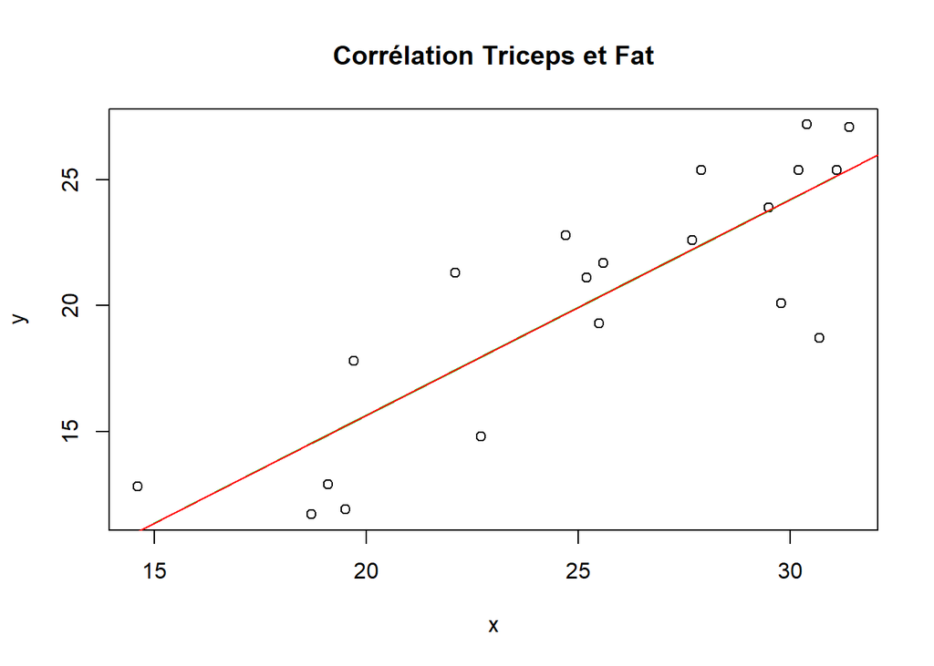

```r
x <- Real_Data$Triceps
y <- Real_Data$Fat
plot(x, y, main = "Corrélation Triceps et Fat")
n <- length(x)
xy <- data.frame(x, y)
a_est <- a_estim(xy, n)
b_est <- b_estim(xy, n)
y_ests <- a_est + b_est*x
lines(x, y_ests, col="green")
regression <- lm(y~x)
abline(regression, col="red")
```

À l’aide du tracé ci-dessus, nous pouvons observer que la droite des moindres carrés suit la droite de régression.

- (Q19) A l’aide de la fonction `confint`, déterminer un estimation par intervalle de confiance des paramètres de la droite de régression.

```r
confint(regression, level=0.95) # avec un intervalle de confiance à 95%
```

```
##                  2.5 %   97.5 %
## (Intercept) -8.4695578 5.477349
## x            0.5866281 1.127745
```

Avec un niveau de confiance à 95%, on peut dire que $b \in [0.587; 1.128]$ et que $a \in [-8.470; 5.477]$

## Qualité de l’ajustement

- (Q20) Déterminer le coefficient $R^2$ de la régression linéaire sur votre jeu de données; qu’en pensez-vous ?

```r
R.squared <- summary(regression)$r.squared
R.squared
```

```
## [1] 0.7110966
```

Le coefficient de détermination permet de mesurer la qualité de l’ajustement de la régression. Ainsi, on peut dire que 71% de la variance des valeurs de la variable est expliquée par la régression sur les variables explicatives. Autrement dit, le modèle de régression explique 71% de la variation observée dans les données.

- (Q21) Vérifier que $R^2= \displaystyle{\frac{s^2_{xy}}{s_x^2s_y^2}}=(\text{ corrélation empirique entre } x \text{ et } y)^2$.

```r
S.2.xy <- (mean(x*y)-mean(x)*mean(y))**2
S.2.x <- mean((x - mean(x))**2)
S.2.y <- mean((y - mean(y))**2)
S.2.xy/(S.2.x * S.2.y)
```

```
## [1] 0.7110966
```

```r
R.squared
```

```
## [1] 0.7110966
```

On trouve que $R^2$ et $\displaystyle{\frac{s^2_{xy}}{s_x^2s_y^2}}$ égales. Notre régression explique en partie la variance de la variable explicative. C’est à dire que la variable `Triceps` explique la variable `Fat`.

- (Q22) Tester si le coefficient de la pente est nul, c-à-d, tester $H_0 : \; b=0$ contre $H_1 \;:$ le complémentaire de $H_0$. Ce problème de test est une des démarches statistiques possibles pour valider le modèle de régression linéaire.

```r
regression$coefficients[2]
```

```
##         x
## 0.8571865
```

$b = 0.8571865$ donc $b \neq 0$. On rejette l’hypothèse $H_0$ et on en conclut qu’il existe une dépendance linéaire entre `Fat` et `Triceps`.

*Indication* : On pourra utiliser la fonction pivotale pour $b$ (cf section I.3 de ce document et/ou Proposition 7.6 du poly CM) ou bien directement la variable dans laquelle est stocké l’objet renvoyé par la fonction “lm”.

## Validation des hypothèses $(\mathcal{ H})$ (cf Section 7.5.4, poly CM)

- (Q23) Evaluer visuellement la normalité des résidus corrigés à l’aide d’un diagramme quantile–quantile (fonctions “qqnorm” et “qqline”).

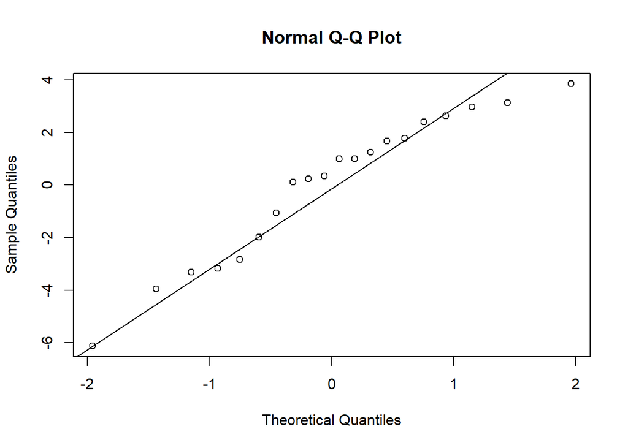

```r
residuals <- residuals(regression)
qqnorm(residuals)
qqline(residuals)
```

Les quantiles théoriques en fonction des quantiles observés suivent à peu près la droite des quantiles–quantiles. Il est possible que notre jeu de données puisse être estimé par une loi normale.

- (Q24) Evaluer visuellement l’indépendance des résidus corrigés et l’hypothèse d’homoscédasticité à l’aide du graphe des résidus corrigés versus la variable explicative.

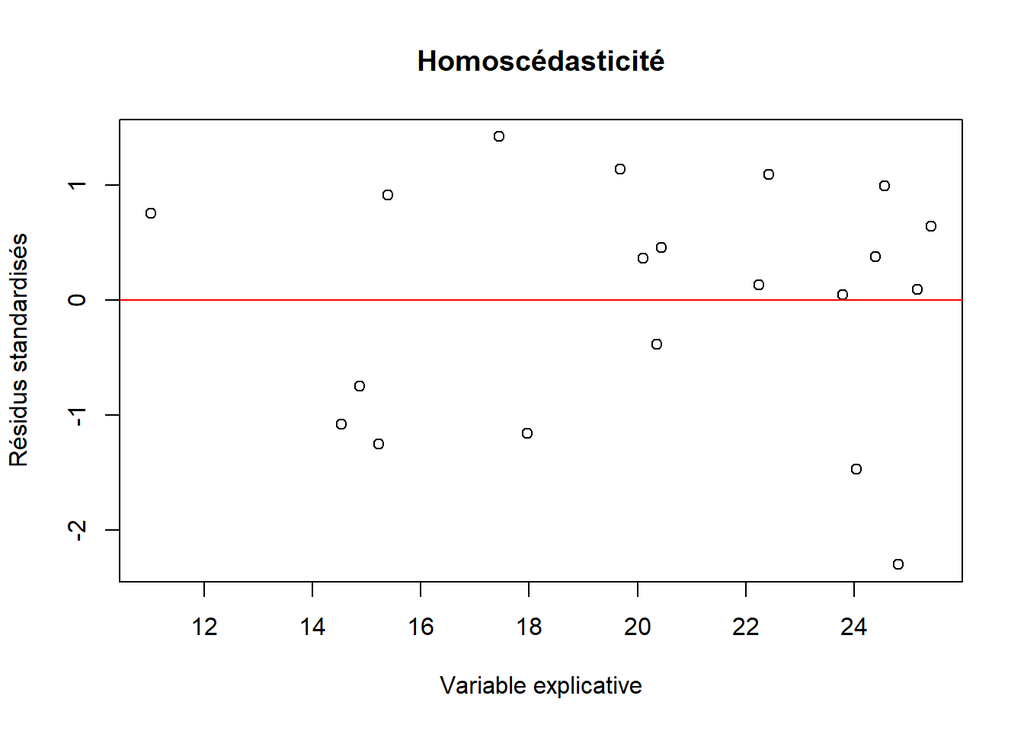

```r
residuals_standardized <- rstandard(regression)
plot(fitted.values(regression), residuals_standardized, main="Homoscédasticité", xlab="Variable explicative", ylab="Résidus standardisés")
abline(h=0, col="red")
```

Nous observons une répartition aléatoire des points sur le graphique (ne semblent pas suivre une fonction particulière). Cela valide l’hypothèse d’homoscédasticité et nous pouvons supposer l’indépendance des résidus corrigés.

## Prévision (cf Section 7.5.5, poly CM)

$\hookrightarrow$ si le modèle proposé semble être pertinent, avec $y={\hat a} + {\hat b}x$ la droite des moindres carrés,

$\hookrightarrow$ et si $x_0$ désigne une nouvelle valeur de $x$ pour laquelle on n’observe pas de réalisation $y_0$ de $Y_0$,

$\Rightarrow$ il s’agit alors de “prédire” la valeur de la variable $Y_0$ qui suit le modèle, $Y_0=a+bx_0 + \epsilon_0$, $\epsilon_0 \sim {\cal N}(0,\sigma^2)$ et où $\epsilon_0$ est indépendante des $\epsilon_i$, $i=1,\ldots,n$.

$\hookrightarrow$ Plus précisément, on s’intéresse à l’estimation ponctuelle de $\mathbb{E}(Y_0)$

- Notation : ${\hat Y}_0={\hat a} + {\hat b}x_0$
- remarquons que $\mathbb{E}({\hat Y}_0)= \mathbb{E}({\hat a} + {\hat b}x_0)= a+bx_0= \mathbb{E} (Y_0)$
- $\Rightarrow$ ${\hat Y}_0$ est alors un **estimateur** sans biais de $\mathbb{E} (Y_0)$
- remarquons que ${\hat Y}_0$ depend, au travers de ${\hat a}$ et ${\hat b}$, de $(Y_1,\ldots,Y_n)$ mais pas de $Y_0$!
- (Q25) Considérer deux nouvelles valeurs de $x$ pour lesquelles on déterminera un intervalle de confiance pour $\mathbb{E}(Y_0)$ au niveau $0.95$ et un intervalle de prédiction au niveau $0.95$.

```r
x0.1 <- 16.8
x0.2 <- 24.0

new_data <- data.frame(x = c(x0.1, x0.2))

# Intervalle de confiance
predict(regression, new_data, interval="confidence", level = 0.95)
```

```
##        fit      lwr      upr
## 1 12.90463 10.24948 15.55978
## 2 19.07637 17.70545 20.44729
```

```r
# Interval de prédiction
predict(regression, new_data, interval="prediction", level = 0.95)
```

```
##        fit       lwr      upr
## 1 12.90463  6.412715 19.39654
## 2 19.07637 12.995702 25.15704
```

Ainsi, nous trouvons à un niveau de confiance de 95% :

- Pour $x_{0,1} = 16.8$ : un intervalle de confiance pour $\mathbb{E}(Y_0) \in [10.2495, 15.5598]$ et un intervalle de prédiction $Y_0 \in [6.4127, 19.3965]$

- Pour $x_{0,2} = 24.0$ un intervalle de confiance $\mathbb{E}(Y_0) \in [17.7055, 20.4473]$ et un intervalle de prédiction $Y_0 \in [12.9957, 25.1570]$

## Conclusion

- (Q26) Votre conclusion en deux ou trois phrases.

De par ces observations et hypothèses, nous en concluons que le modèle de régression linéaire est adapté à nos données.

Ainsi, nous avons déterminé que nous pouvons, à partir du pli du triceps d’un individu, prédire un encadrement de sa masse graisseuse à un niveau de confiance choisi.